# Week 3 - Homework

STAT 420, Summer 2017, Xiaoming Ji

## Exercise 1 (Using `lm` for Inference)

For this exercise we will use the `cats` dataset from the `MASS` package. You should use `?cats` to learn about the background of this dataset.

**(a)** Fit the following simple linear regression model in `R`. Use heart weight as the response and body weight as the predictor.

$$Y_i = \beta_0 + \beta_1 x_i + \epsilon_i$$

Store the results in a variable called `cat_model`. Use a $t$ test to test the significance of the regression. Report the following:

- The null and alternative hypotheses
- The value of the test statistic
- The p-value of the test
- A statistical decision at $\alpha = 0.01$
- A conclusion in the context of the problem

When reporting these, you should explicitly state them in your document, not assume that a reader will find and interpret them from a large block of `R` output.

```r
library("MASS")
cat_model = lm(Hwt ~ Bwt, data = cats)
coefficient = summary(cat_model)$coefficient
coefficient[2,]
```

```
##     Estimate   Std. Error      t value     Pr(>|t|)
## 4.034063e+00 2.502615e-01 1.611939e+01 6.969045e-34
```

**Answer:**
$$H_0: \beta_1 = 0 \quad \text{vs} \quad H_1: \beta_1 \neq 0$$

- Under $H_0$ (null hypotheses ) there is not a significant linear relationship between body weight and heart weight.
- Under $H_1$ (alternative hypotheses) there is a significant linear relationship between body weight and heart weight.
- Test statistic, t = 16.1193908
- p-value of the test, p-value = 6.969045e-34
- With this extremely low p-value,we would **reject** the null hypothesis at $\alpha = 0.01$
- We would say there is a significant linear relationship between body weight and heart weight

**(b)** Calculate a 99% confidence interval for $\beta_1$. Give an interpretation of the interval in the context of the problem.

```r
range = confint(cat_model, level=0.99)[2,]
```

**Answer:** We are 99% confident that for an increase in body weight of 1kg, the average increase in heart weight is between 3.3806562g and 4.6874692g

**(c)** Calculate a 90% confidence interval for $\beta_0$. Give an interpretation of the interval in the context of the problem.

```r
range = confint(cat_model, level=0.90)[1,]
```

**Answer:** We are 90% confident that mean of $\beta_0$ is within the range from -1.5028345 to 0.7895096

**(d)** Use a 95% confidence interval to estimate the mean heart weight for body weights of 2.5 and 3.0 kilograms Which of the two intervals is wider? Why?

```r
new_bwt = data.frame(Bwt = c(2.5, 3.0))
range = predict(cat_model, newdata = new_bwt,
        interval = c("confidence"), level = 0.95)

abs(range[,2] - range[,3])
```

```
##         1         2
## 0.5271854 0.5511433
```

**Answer:** body weight of 3.0 is wider because body weight of 2.5 is closer to mean of body weight (2.7236111)

**(e)** Use a 95% prediction interval to predict the heart weight for body weights of 2.5 and 4.0 kilograms.

```r
new_bwt = data.frame(Bwt = c(2.5, 4.0))
range = predict(cat_model, newdata = new_bwt,
        interval = c("prediction"), level = 0.95)
```

**Answer:**

- body weight of 2.5 gives us the 95% prediction interval as (6.8453519, 12.6116367)
- body weight of 4.0 gives us the 95% prediction interval as (12.8301804, 18.7289963)

**(f)** Create a scatterplot of the data. Add the regression line, 95% confidence bands, and 95% prediction bands.

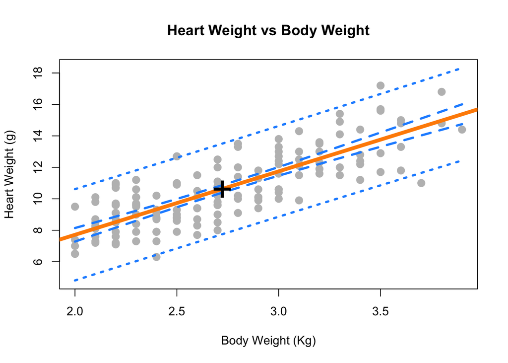

```r
bwt_grid = seq(min(cats$Bwt), max(cats$Bwt), by = 0.1)
hwt_ci_band = predict(cat_model,
                       newdata = data.frame(Bwt = bwt_grid),
                       interval = "confidence", level = 0.95)
hwt_pi_band = predict(cat_model,
                       newdata = data.frame(Bwt = bwt_grid),
                       interval = "prediction", level = 0.95)

plot(Hwt ~ Bwt, data = cats,
     xlab = "Body Weight (Kg)",
     ylab = "Heart Weight (g)",
     main = "Heart Weight vs Body Weight",
     pch  = 20,
     cex  = 2,
     col  = "grey",
     ylim = c(min(hwt_pi_band), max(hwt_pi_band)))
abline(cat_model, lwd = 5, col = "darkorange")

lines(bwt_grid, hwt_ci_band[,"lwr"], col = "dodgerblue", lwd = 3, lty = 2)
lines(bwt_grid, hwt_ci_band[,"upr"], col = "dodgerblue", lwd = 3, lty = 2)
lines(bwt_grid, hwt_pi_band[,"lwr"], col = "dodgerblue", lwd = 3, lty = 3)
lines(bwt_grid, hwt_pi_band[,"upr"], col = "dodgerblue", lwd = 3, lty = 3)
points(mean(cats$Bwt), mean(cats$Hwt), pch = "+", cex = 3)
```

## Exercise 2 (Using `lm` for Inference)

For this exercise we will use the `diabetes` dataset, which can be found in the `faraway` package.

**(a)** Fit the following simple linear regression model in `R`. Use the total cholesterol as the response and weight as the predictor.

$$Y_i = \beta_0 + \beta_1 x_i + \epsilon_i$$

Store the results in a variable called `cholesterol_model`. Use a $t$ test to test the significance of the regression. Report the following:

- The null and alternative hypotheses
- The value of the test statistic
- The p-value of the test
- A statistical decision at $\alpha = 0.05$
- A conclusion in the context of the problem

When reporting these, you should explicitly state them in your document, not assume that a reader will find and interpret them from a large block of `R` output.

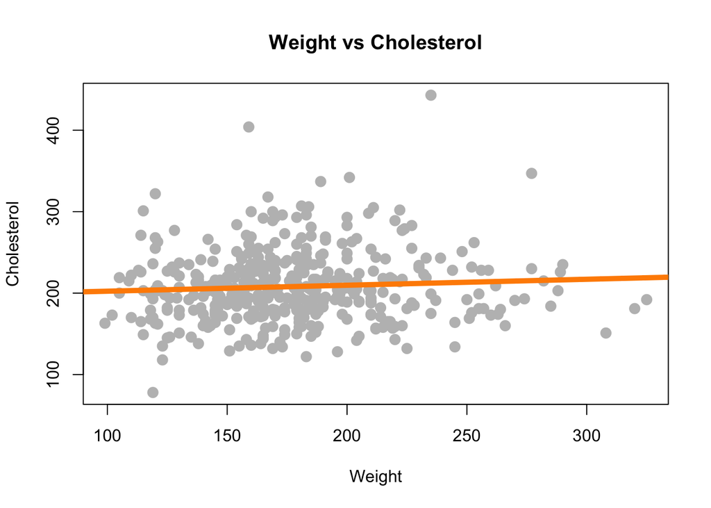

```r
library("faraway")
cholesterol_model = lm(chol ~ weight, data = diabetes)
plot(chol ~ weight, data = diabetes,
     xlab = "Weight",
     ylab = "Cholesterol",
     main = "Weight vs Cholesterol",
     pch  = 20,
     cex  = 2,
     col  = "grey")
abline(cholesterol_model, lwd = 5, col = "darkorange")
```

```r
coefficient = summary(cholesterol_model)$coefficient
coefficient[2,]
```

```
##   Estimate Std. Error    t value   Pr(>|t|)
##  0.0736330  0.0549871  1.3390958  0.1813018
```

**Answer:**
$$H_0: \beta_1 = 0 \quad \text{vs} \quad H_1: \beta_1 \neq 0$$

- Under $H_0$ (null hypotheses ) there is not a significant linear relationship between weight and total cholesterol.
- Under $H_1$ (alternative hypotheses) there is a significant linear relationship between weight and total cholesterol.
- Test statistic, t = 1.3390958
- p-value of the test, p-value = 0.1813018
- With this large p-value,we would **fail to reject** the null hypothesis at $\alpha = 0.05$
- We would say there is no significant linear relationship between weight and total cholesterol.

**(b)** Fit the following simple linear regression model in `R`. Use HDL as the response and weight as the predictor.

$$Y_i = \beta_0 + \beta_1 x_i + \epsilon_i$$

Store the results in a variable called `hdl_model`. Use a $t$ test to test the significance of the regression. Report the following:

- The null and alternative hypotheses
- The value of the test statistic
- The p-value of the test
- A statistical decision at $\alpha = 0.05$
- A conclusion in the context of the problem

When reporting these, you should explicitly state them in your document, not assume that a reader will find and interpret them from a large block of `R` output.

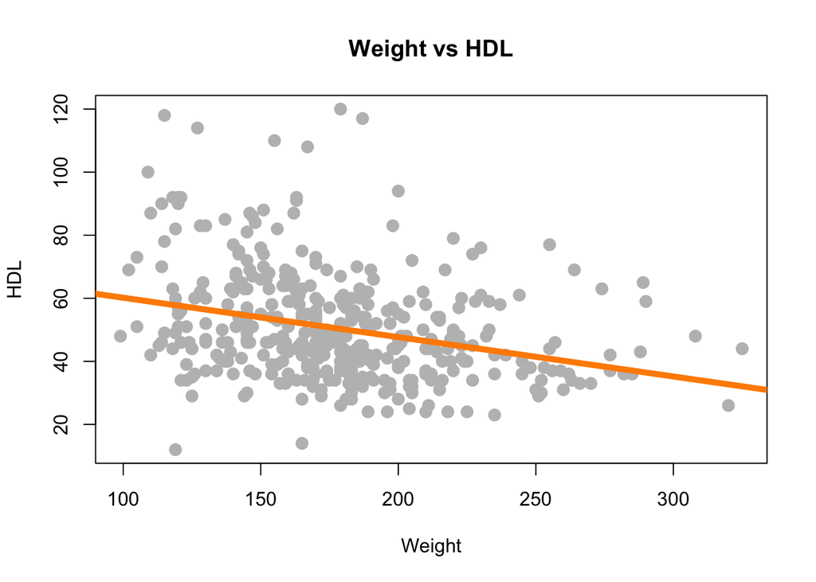

```r
hdl_model = lm(hdl ~ weight, data = diabetes)
plot(hdl ~ weight, data = diabetes,
     xlab = "Weight",
     ylab = "HDL",
     main = "Weight vs HDL",
     pch  = 20,
     cex  = 2,
     col  = "grey")
abline(hdl_model, lwd = 5, col = "darkorange")
```

```r
coefficient = summary(hdl_model)$coefficient
coefficient[2,]
```

```
##      Estimate    Std. Error       t value      Pr(>|t|)
## -1.249879e-01  2.057327e-02 -6.075257e+00  2.890526e-09
```

**Answer:**
$$H_0: \beta_1 = 0 \quad \text{vs} \quad H_1: \beta_1 \neq 0$$

- Under $H_0$ (null hypotheses ) there is not a significant linear relationship between weight and HDL.
- Under $H_1$ (alternative hypotheses) there is a significant linear relationship between weight and HDL.
- Test statistic, t = -6.0752572
- p-value of the test, p-value = 2.890526e-09
- With this small p-value,we would **reject** the null hypothesis at $\alpha = 0.05$
- We would say there is a significant linear relationship between weight and HDL.

## Exercise 3 (Inference “without” `lm`)

Write a function named `get_p_val_beta_1` that performs the test

$$H_0: \beta_1 = \beta_{10} \quad \text{vs} \quad H_1: \beta_1 \neq \beta_{10}$$

for the linear model

$$Y_i = \beta_0 + \beta_1 x_i + \epsilon_i.$$

The function should take two inputs:

- A model object that is the result of fitting the SLR model with `lm()`
- A hypothesized value of $\beta_1$, $\beta_{10}$, with a default value of 0

The function should return a named vector with elements:

- `t`, which stores the value of the test statistic for performing the test
- `p_val`, which stores the p-value for performing the test

```r
get_p_val_beta_1 = function(model, beta_1 = 0) {
  beta_1_est = summary(model)$coefficient[2,1]
  se_beta_1 = summary(model)$coefficient[2,2]
  t = (beta_1_est - beta_1) / se_beta_1
  p_value = 2 * pt(abs(t), length(resid(model)) - 2, lower.tail = FALSE)
  value = c(t, p_value)
  names(value) = c("t", "p_val")
  value
}
```

**(a)** After writing the function, run these three lines of code:

```r
get_p_val_beta_1(cat_model, beta_1 = 4.2)
```

```
##          t      p_val
## -0.6630557  0.5083698
```

```r
get_p_val_beta_1(cholesterol_model)
```

```
##         t     p_val
## 1.3390958 0.1813018
```

```r
get_p_val_beta_1(hdl_model)
```

```
##             t         p_val
## -6.075257e+00  2.890526e-09
```

**(b)** Return to the goalies dataset from the previous homework, which is stored in `goalies.csv`. Fit a simple linear regression model with `W` as the response and `MIN` as the predictor. Store the results in a variable called `goalies_model_min`. After doing so, run these three lines of code:

```r
library(readr)
goalies = read_csv("goalies.csv")
goalies_model_min = lm(W ~ MIN, data = goalies)

get_p_val_beta_1(goalies_model_min)
```

```
##       t   p_val
## 154.724   0.000
```

```r
get_p_val_beta_1(goalies_model_min, beta_1 = coef(goalies_model_min)[2])
```

```
##     t p_val
##     0     1
```

```r
get_p_val_beta_1(goalies_model_min, beta_1 = 0.008)
```

```
##            t        p_val
## -3.036956036  0.002477199
```

## Exercise 4 (Simulating Sampling Distributions)

For this exercise we will simulate data from the following model:

$$Y_i = \beta_0 + \beta_1 x_i + \epsilon_i$$

Where $\epsilon_i \sim N(0, \sigma^2).$ Also, the parameters are known to be:

- $\beta_0 = 3$
- $\beta_1 = 0.75$
- $\sigma^2 = 25$

We will use samples of size $n = 42$.

**(a)** Simulate this model $1500$ times. Each time use `lm()` to fit a simple linear regression model, then store the value of $\hat{\beta}_0$ and $\hat{\beta}_1$. Set a seed using **your** birthday before performing the simulation. Note, we are simulating the $x$ values once, and then they remain fixed for the remainder of the exercise.

```r
beta_0 = 3
beta_1 = 0.75
sigma = 5

birthday = 19720816
set.seed(birthday)

num_samples = 1500
sample_size = 42

sim_slr = function(x, beta_0 = 10, beta_1 = 5, sigma = 1) {
  n = length(x)
  epsilon = rnorm(n, mean = 0, sd = sigma)
  y = beta_0 + beta_1 * x + epsilon
  data.frame(predictor = x, response = y)
}

x = seq(0, 20, length = sample_size)

beta_0_hats = rep(0, num_samples)
beta_1_hats = rep(0, num_samples)

for(i in 1:num_samples) {
  model_data = sim_slr(x, beta_0, beta_1, sigma)
  sim_model = lm(response ~ predictor, data = model_data)

  beta_0_hats[i] = coef(sim_model)[1]
  beta_1_hats[i] = coef(sim_model)[2]
}

Sxx = sum((x - mean(x)) ^ 2)

true_beta_0_hat_sd = sigma * sqrt(1 / sample_size + mean(x) ^ 2 / Sxx)
true_beta_1_hat_sd = sigma / sqrt(Sxx)
```

**(b)** For the *known* values of $x$, what is the expected value of $\hat{\beta}_1$?

**Answer:** 0.75

**(c)** For the known values of $x$, what is the standard deviation of $\hat{\beta}_1$?

**Answer:** 0.1304859

**(d)** What is the mean of your simulated values of $\hat{\beta}_1$? Does this make sense given your answer in **(b)**?

**Answer:** 0.7501706. Yes, they are very close.

**(e)** What is the standard deviation of your simulated values of $\hat{\beta}_1$? Does this make sense given your answer in **(c)**?

**Answer:** 0.1239935. Yes, although the gap is not neglectable, increasing the number of samples can narrow such gap. For example, if we increaes the number of samples to 15,000, we get 0.1304812.

**(f)** For the known values of $x$, what is the expected value of $\hat{\beta}_0$?

**Answer:** 3

**(g)** For the known values of $x$, what is the standard deviation of $\hat{\beta}_0$?

**Answer:** 1.5158812

**(h)** What is the mean of your simulated values of $\hat{\beta}_0$? Does this make sense given your answer in **(f)**?

**Answer:** 2.9967088. Yes, they are very close.

**(i)** What is the standard deviation of your simulated values of $\hat{\beta}_0$? Does this make sense given your answer in **(g)**?

**Answer:** 1.4644087. Yes, although the gap is not neglectable, increasing the number of samples can narrow such gap. For example, if we increaes the number of samples to 15,000, we get 1.5176132.

**(j)** Plot a histogram of your simulated values for $\hat{\beta}_1$. Add the normal curve for the true sampling distribution of $\hat{\beta}_1$.

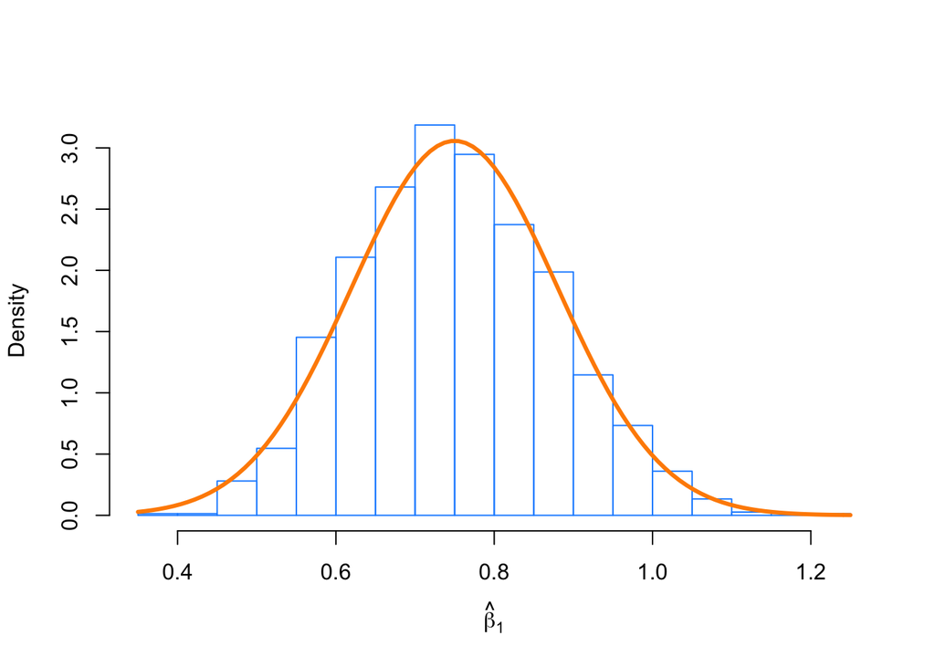

```r
hist(beta_1_hats, prob = TRUE, breaks = 20,
     xlab = expression(hat(beta)[1]), main = "", border = "dodgerblue")
curve(dnorm(x, mean = beta_1, sd = true_beta_1_hat_sd),
      col = "darkorange", add = TRUE, lwd = 3)
```

**(k)** Plot a histogram of your simulated values for $\hat{\beta}_0$. Add the normal curve for the true sampling distribution of $\hat{\beta}_0$.

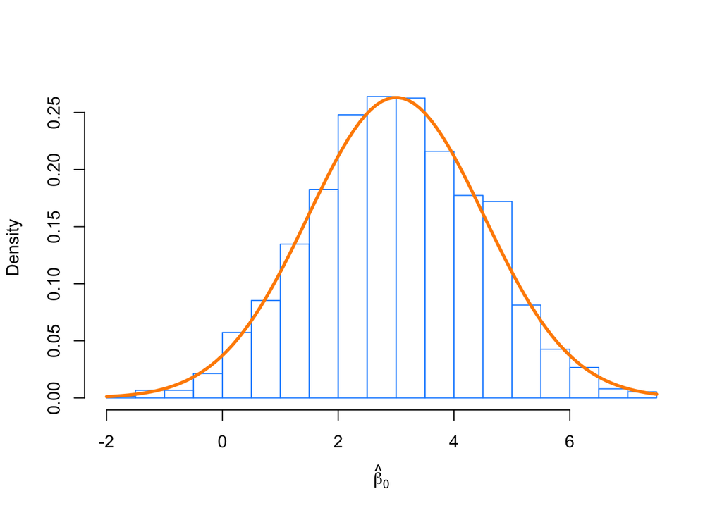

```r
hist(beta_0_hats, prob = TRUE, breaks = 20,
     xlab = expression(hat(beta)[0]), main = "", border = "dodgerblue")
curve(dnorm(x, mean = beta_0, sd = true_beta_0_hat_sd),
      col = "darkorange", add = TRUE, lwd = 3)
```

## Exercise 5 (Simulating Confidence Intervals)

For this exercise we will simulate data from the following model:

$$Y_i = \beta_0 + \beta_1 x_i + \epsilon_i$$

Where $\epsilon_i \sim N(0, \sigma^2).$ Also, the parameters are known to be:

- $\beta_0 = 1$
- $\beta_1 = 3$
- $\sigma^2 = 16$

We will use samples of size $n = 20$.

Our goal here is to use simulation to verify that the confidence intervals really do have their stated confidence level. Do **not** use the `confint()` function for this entire exercise.

**(a)** Simulate this model $2000$ times. Each time use `lm()` to fit a simple linear regression model, then store the value of $\hat{\beta}_0$ and $s_e$. Set a seed using **your** birthday before performing the simulation. Note, we are simulating the $x$ values once, and then they remain fixed for the remainder of the exercise.

```r
beta_0 = 1
beta_1 = 3
sigma = 4

birthday = 19720816
set.seed(birthday)

num_samples = 2000
sample_size = 20

x = seq(-5, 5, length = sample_size)

beta_0_hats = rep(0, num_samples)
#beta_0_ses = rep(0, num_samples)
ses = rep(0, num_samples)

for(i in 1:num_samples) {
  model_data = sim_slr(x, beta_0, beta_1, sigma)
  sim_model = lm(response ~ predictor, data = model_data)

  beta_0_hats[i] = coef(sim_model)[1]
  #beta_0_ses[i] = summary(sim_model)$coefficient[1,2]
  ses[i] = summary(sim_model)$sigma
}

Sxx = sum((x - mean(x)) ^ 2)
beta_0_ses = ses * sqrt(1 / sample_size + mean(x) ^2 / Sxx)
```

**(b)** For each of the $\hat{\beta}_0$ that you simulated, calculate a 90% confidence interval. Store the lower limits in a vector `lower_90` and the upper limits in a vector `upper_90`. Some hints:

- You will need to use `qt()` to calculate the critical value, which will be the same for each interval.
- Remember that `x` is fixed, so $S_{xx}$ will be the same for each interval.
- You could, but do not need to write a `for` loop. Remember vectorized operations.

```r
crit = qt(0.95, df = sample_size - 2)
lower_90 = beta_0_hats - crit * beta_0_ses
upper_90 = beta_0_hats + crit * beta_0_ses
```

**(c)** What proportion of these intervals contain the true value of $\beta_0$?

```r
p = sum(beta_0 > lower_90 & beta_0 < upper_90) / num_samples
```

**Answer:** 0.9075

**(d)** Based on these intervals, what proportion of the simulations would reject the test $H_0: \beta_0 = 0$ vs $H_1: \beta_0 \neq 0$ at $\alpha = 0.10$?

```r
p = sum(0 < lower_90 | 0 > upper_90) / num_samples
```

**Answer:** 0.275

**(e)** For each of the $\hat{\beta}_0$ that you simulated, calculate a 99% confidence interval. Store the lower limits in a vector `lower_99` and the upper limits in a vector `upper_99`.

```r
crit = qt(0.995, df = sample_size - 2)
lower_99 = beta_0_hats - crit * beta_0_ses
upper_99 = beta_0_hats + crit * beta_0_ses
```

**(f)** What proportion of these intervals contain the true value of $\beta_0$?

```r
p = sum(beta_0 > lower_99 & beta_0 < upper_99) / num_samples
```

**Answer:** 0.9895

**(g)** Based on these intervals, what proportion of the simulations would reject the test $H_0: \beta_0 = 0$ vs $H_1: \beta_0 \neq 0$ at $\alpha = 0.01$?

```r
p = sum(0 < lower_99 | 0 > upper_99) / num_samples
```

**Answer:** 0.0635